# Air Humidity Caase Study

Sara de la Sota Alonso

Predictive modeling UC3M, Dec 2023

# Introduction

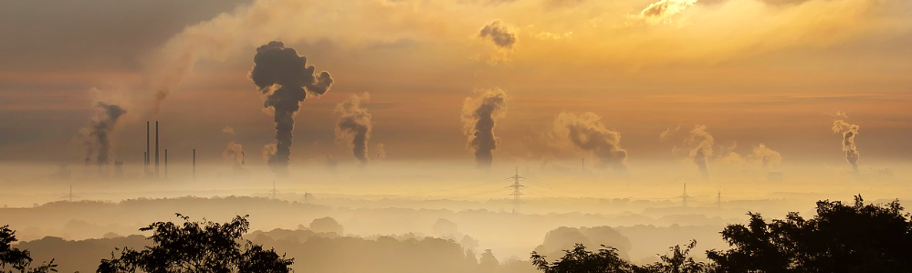

## The dataset

Data source: https://archive.ics.uci.edu/dataset/360/air+quality

The dataset AirQualityUCI.csv includes the following 15 variables: -Date: (String) Date of the recording (MM/DD/YYYY). -Time: (String) Time of the recording (HH:MM:SS). -CO.GT.: (Integer) True hourly averaged concentration CO in mg/m^3. -PT08.S1.CO: (Categorical) hourly averaged sensor response (nominally CO targeted). -NMHC.GT.: (Integer) True hourly averaged overall Non Metanic HydroCarbons concentration in microg/m^3. -C6H6.GT.: (Continuous) True hourly averaged Benzene concentration in microg/m^3. -PT08.S2.NMHC.: (Categorical) hourly averaged sensor response (nominally NMHC targeted). -NOx.GT.: (Integer) True hourly averaged NOx concentration in ppb. -PT08.S3.NOx.: (Categorical) hourly averaged sensor response (nominally NOx targeted). -NO2.GT.: (Integer) True hourly averaged NO2 concentration in microg/m^3. -PT08.S4.NO2.: (Categorical) hourly averaged sensor response (nominally NO2 targeted). -PT08.S5.O3.: (Categorical) hourly averaged sensor response (nominally O3 targeted). -T: (Continuous) Temperature measured in Celsius degrees. -RH: (Continuous) Relative humidity in percentage. -AH: (Continuous) Absolute humidity.

## The goal of this project

The aim of this project is to predict the relative humidity.

### Data preparation

```r
#Load the necessary libraries
library(tidyverse)
library(MASS)
library(caret)
library(e1071)
library(lubridate)
library(dplyr)
library(ggplot2)

df_air = read.csv("AirQualityUCI.csv")

# Display the data types of columns in df_air
str(df_air)
```

```
## 'data.frame':    9471 obs. of  17 variables:
##  $ Date         : chr  "3/10/2004" "3/10/2004" "3/10/2004" "3/10/2004" ...
##  $ Time         : chr  "18:00:00" "19:00:00" "20:00:00" "21:00:00" ...
##  $ CO.GT.       : num  2.6 2 2.2 2.2 1.6 1.2 1.2 1 0.9 0.6 ...
##  $ PT08.S1.CO.  : int  1360 1292 1402 1376 1272 1197 1185 1136 1094 1010 ...
##  $ NMHC.GT.     : int  150 112 88 80 51 38 31 31 24 19 ...
##  $ C6H6.GT.     : num  11.9 9.4 9 9.2 6.5 4.7 3.6 3.3 2.3 1.7 ...
##  $ PT08.S2.NMHC.: int  1046 955 939 948 836 750 690 672 609 561 ...
##  $ NOx.GT.      : int  166 103 131 172 131 89 62 62 45 -200 ...
##  $ PT08.S3.NOx. : int  1056 1174 1140 1092 1205 1337 1462 1453 1579 1705 ...
##  $ NO2.GT.      : int  113 92 114 122 116 96 77 76 60 -200 ...
##  $ PT08.S4.NO2. : int  1692 1559 1555 1584 1490 1393 1333 1333 1276 1235 ...
##  $ PT08.S5.O3.  : int  1268 972 1074 1203 1110 949 733 730 620 501 ...
##  $ T            : num  13.6 13.3 11.9 11 11.2 11.2 11.3 10.7 10.7 10.3 ...
##  $ RH           : num  48.9 47.7 54 60 59.6 59.2 56.8 60 59.7 60.2 ...
##  $ AH           : num  0.758 0.726 0.75 0.787 0.789 ...
##  $ X            : logi  NA NA NA NA NA NA ...
##  $ X.1          : logi  NA NA NA NA NA NA ...
```

```r
# Count NaN values in each column
nan_counts <- colSums(is.na(df_air))

# Print the result
print(nan_counts)
```

```
##          Date          Time        CO.GT.   PT08.S1.CO.      NMHC.GT.
##             0             0           114           114           114
##      C6H6.GT. PT08.S2.NMHC.       NOx.GT.  PT08.S3.NOx.       NO2.GT.
##           114           114           114           114           114
##  PT08.S4.NO2.   PT08.S5.O3.             T            RH            AH
##           114           114           114           114           114
##             X           X.1
##          9471          9471
```

Let’s delete the instances and the columns with null values:

```r
# Delete the last two columns
df_air <- df_air[, -c((ncol(df_air) - 1):ncol(df_air))]

# Drop rows with all NaN values
df_air <- na.omit(df_air)

# Drop rows with NaN values in the 'RH' column
df_air <- df_air[complete.cases(df_air$RH), ]

# Count NaN values in each column after cleaning
nan_counts <- colSums(is.na(df_air))

# Print the result
print(nan_counts)
```

```
##          Date          Time        CO.GT.   PT08.S1.CO.      NMHC.GT.
##             0             0             0             0             0
##      C6H6.GT. PT08.S2.NMHC.       NOx.GT.  PT08.S3.NOx.       NO2.GT.
##             0             0             0             0             0
##  PT08.S4.NO2.   PT08.S5.O3.             T            RH            AH
##             0             0             0             0             0
```

In order to consider the hour and the month as features of hour problem we will convert the columns and extract the values and add them as a new feature.

```r
# Convert the date string into a dmy object
df_air$Date <- mdy(df_air$Date)
str(df_air)
```

```
## 'data.frame':    9357 obs. of  15 variables:
##  $ Date         : Date, format: "2004-03-10" "2004-03-10" ...
##  $ Time         : chr  "18:00:00" "19:00:00" "20:00:00" "21:00:00" ...
##  $ CO.GT.       : num  2.6 2 2.2 2.2 1.6 1.2 1.2 1 0.9 0.6 ...
##  $ PT08.S1.CO.  : int  1360 1292 1402 1376 1272 1197 1185 1136 1094 1010 ...
##  $ NMHC.GT.     : int  150 112 88 80 51 38 31 31 24 19 ...
##  $ C6H6.GT.     : num  11.9 9.4 9 9.2 6.5 4.7 3.6 3.3 2.3 1.7 ...
##  $ PT08.S2.NMHC.: int  1046 955 939 948 836 750 690 672 609 561 ...
##  $ NOx.GT.      : int  166 103 131 172 131 89 62 62 45 -200 ...
##  $ PT08.S3.NOx. : int  1056 1174 1140 1092 1205 1337 1462 1453 1579 1705 ...
##  $ NO2.GT.      : int  113 92 114 122 116 96 77 76 60 -200 ...
##  $ PT08.S4.NO2. : int  1692 1559 1555 1584 1490 1393 1333 1333 1276 1235 ...
##  $ PT08.S5.O3.  : int  1268 972 1074 1203 1110 949 733 730 620 501 ...
##  $ T            : num  13.6 13.3 11.9 11 11.2 11.2 11.3 10.7 10.7 10.3 ...
##  $ RH           : num  48.9 47.7 54 60 59.6 59.2 56.8 60 59.7 60.2 ...
##  $ AH           : num  0.758 0.726 0.75 0.787 0.789 ...
##  - attr(*, "na.action")= 'omit' Named int [1:114] 9358 9359 9360 9361 9362 9363 9364 9365 9366 9367 ...
##   ..- attr(*, "names")= chr [1:114] "9358" "9359" "9360" "9361" ...
```

```r
# Create a new feature with only the month
df_air$Month <- month(df_air$Date)

# Convert the time string to an hms object
df_air$Time <- hms(df_air$Time)
# Create a new feature with only the hour
df_air$Hour <- hour(df_air$Time)
```

Missing values are tagged with -200 value. So we will replace the values tagged as -200 of each feature with the median. The instances with relative humidity (RH) equal to -200 will be removed from the dataset.

```r
# Replace values equal to -200 with NA in the 'RH' column
df_air$RH[df_air$RH == -200] <- NA

# Remove rows where 'RH' is NA
df_air <- df_air[!is.na(df_air$RH), ]

# Replace CO.GT. values equal to -200 with NA
df_air$CO.GT.[df_air$CO.GT. == -200.0] <- NA

# Group by hour and calculate the median for each group
df_air <- within(df_air, {
  CO.GT. <- ifelse(is.na(CO.GT.), ave(CO.GT., Hour, FUN = function(x) median(x, na.rm = TRUE)), CO.GT.)
})

# Replace PT08.S1.CO. values equal to -200 with NA
df_air$PT08.S1.CO.[df_air$PT08.S1.CO. == -200.0] <- NA

# Group by hour and calculate the median for each group
df_air <- within(df_air, {
  PT08.S1.CO. <- ifelse(is.na(PT08.S1.CO.), ave(PT08.S1.CO., Hour, FUN = function(x) median(x, na.rm = TRUE)), PT08.S1.CO.)
})

# Replace NMHC.GT. values equal to -200 with NA
df_air$NMHC.GT.[df_air$NMHC.GT. == -200.0] <- NA

# Group by hour and calculate the median for each group
df_air <- within(df_air, {
  NMHC.GT. <- ifelse(is.na(NMHC.GT.), ave(NMHC.GT., Hour, FUN = function(x) median(x, na.rm = TRUE)), NMHC.GT.)
})

# Replace C6H6.GT. values equal to -200 with NA
df_air$C6H6.GT.[df_air$C6H6.GT. == -200.0] <- NA

# Group by hour and calculate the median for each group
df_air <- within(df_air, {
  C6H6.GT. <- ifelse(is.na(C6H6.GT.), ave(C6H6.GT., Hour, FUN = function(x) median(x, na.rm = TRUE)), C6H6.GT.)
})

# Replace PT08.S2.NMHC. values equal to -200 with NA
df_air$PT08.S2.NMHC.[df_air$PT08.S2.NMHC. == -200.0] <- NA

# Group by hour and calculate the median for each group
df_air <- within(df_air, {
  PT08.S2.NMHC. <- ifelse(is.na(PT08.S2.NMHC.), ave(PT08.S2.NMHC., Hour, FUN = function(x) median(x, na.rm = TRUE)), PT08.S2.NMHC.)
})

# Replace NOx.GT. values equal to -200 with NA
df_air$NOx.GT.[df_air$NOx.GT. == -200.0] <- NA

# Group by hour and calculate the median for each group
df_air <- within(df_air, {
  NOx.GT. <- ifelse(is.na(NOx.GT.), ave(NOx.GT., Hour, FUN = function(x) median(x, na.rm = TRUE)), NOx.GT.)
})

# Replace PT08.S3.NOx. values equal to -200 with NA
df_air$PT08.S3.NOx.[df_air$PT08.S3.NOx. == -200.0] <- NA

# Group by hour and calculate the median for each group
df_air <- within(df_air, {
  PT08.S3.NOx. <- ifelse(is.na(PT08.S3.NOx.), ave(PT08.S3.NOx., Hour, FUN = function(x) median(x, na.rm = TRUE)), PT08.S3.NOx.)
})

# Replace NO2.GT. values equal to -200 with NA
df_air$NO2.GT.[df_air$NO2.GT. == -200.0] <- NA

# Group by hour and calculate the median for each group
df_air <- within(df_air, {
  NO2.GT. <- ifelse(is.na(NO2.GT.), ave(NO2.GT., Hour, FUN = function(x) median(x, na.rm = TRUE)), NO2.GT.)
})

# Replace PT08.S4.NO2. values equal to -200 with NA
df_air$PT08.S4.NO2.[df_air$PT08.S4.NO2. == -200.0] <- NA

# Group by hour and calculate the median for each group
df_air <- within(df_air, {
  PT08.S4.NO2. <- ifelse(is.na(PT08.S4.NO2.), ave(PT08.S4.NO2., Hour, FUN = function(x) median(x, na.rm = TRUE)), PT08.S4.NO2.)
})

# Replace PT08.S4.NO2. values equal to -200 with NA
df_air$PT08.S4.NO2.[df_air$PT08.S4.NO2. == -200.0] <- NA

# Group by hour and calculate the median for each group
df_air <- within(df_air, {
  PT08.S4.NO2. <- ifelse(is.na(PT08.S4.NO2.), ave(PT08.S4.NO2., Hour, FUN = function(x) median(x, na.rm = TRUE)), PT08.S4.NO2.)
})

# Replace PT08.S5.O3. values equal to -200 with NA
df_air$PT08.S5.O3.[df_air$PT08.S5.O3. == -200.0] <- NA

# Group by hour and calculate the median for each group
df_air <- within(df_air, {
  PT08.S5.O3. <- ifelse(is.na(PT08.S5.O3.), ave(PT08.S5.O3., Hour, FUN = function(x) median(x, na.rm = TRUE)), PT08.S5.O3.)
})

# Replace T values equal to -200 with NA
df_air$T[df_air$T == -200.0] <- NA

# Group by hour and calculate the median for each group
df_air <- within(df_air, {
  T <- ifelse(is.na(T), ave(T, Hour, FUN = function(x) median(x, na.rm = TRUE)), T)
})

# Replace AH values equal to -200 with NA
df_air$AH[df_air$AH == -200.0] <- NA

# Group by hour and calculate the median for each group
df_air <- within(df_air, {
  AH <- ifelse(is.na(AH), ave(AH, Hour, FUN = function(x) median(x, na.rm = TRUE)), AH)
})
```

### Explanatory analysis

```r
# split between training and testing sets
spl = createDataPartition(df_air$RH, p = 0.7, list = FALSE)  # 70% for training

df_air_train = df_air[spl,]
df_air_test = df_air[-spl,]
```

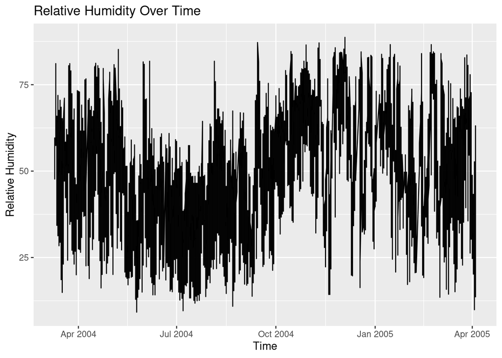

```r
# Create a line plot of 'RH' over time
ggplot(df_air_train, aes(x = Date, y = RH)) +
  geom_line() +
  labs(title = "Relative Humidity Over Time",
       x = "Time",
       y = "Relative Humidity")
```

For our model we will use the features Month and Hour and not the Date and Time variables.

```r
# Eliminate the first two columns
df_air_train <- df_air_train[, -c(1, 2)]
df_air_test<- df_air_test[, -c(1, 2)]
```

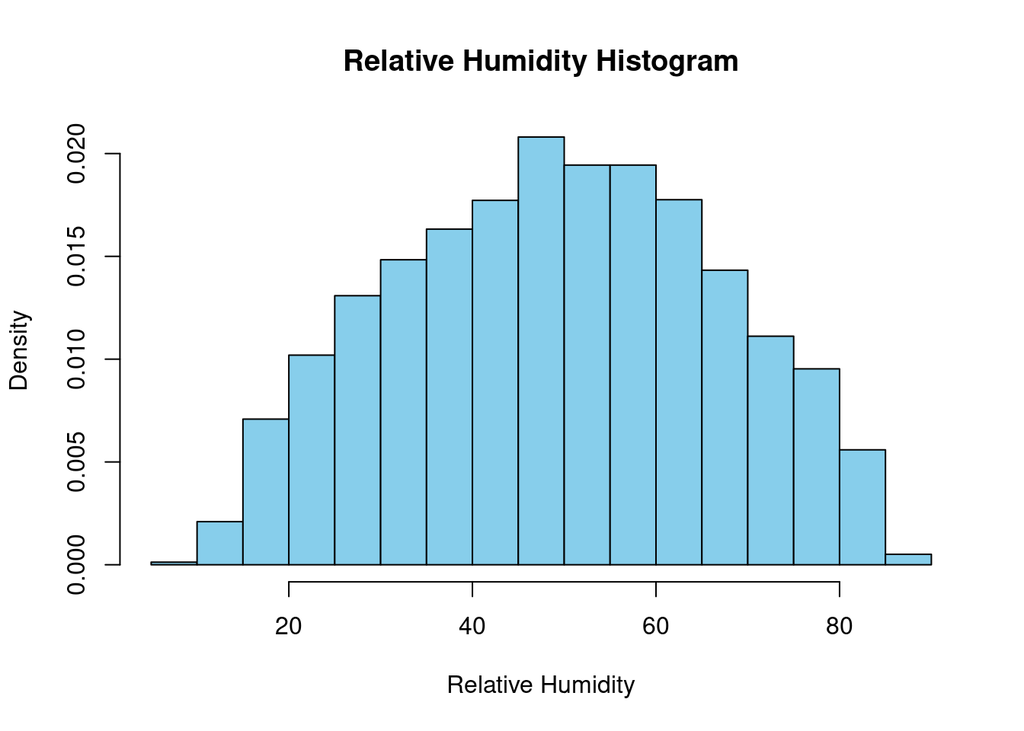

```r
# Create a histogram with relative frequencies of the 'RH' column
hist(df_air_train$RH, main = "Relative Humidity Histogram", xlab = "Relative Humidity", col = "skyblue", border = "black", freq = FALSE)
```

See that the distribution is symmetric so we can check if it is better to use the logarithm but if it is symetric it is not necessary to use the logarithm.

We need a naive prediction so we predict with the mean. And the interval, the width. with regression we are going to reduce the error, the width.

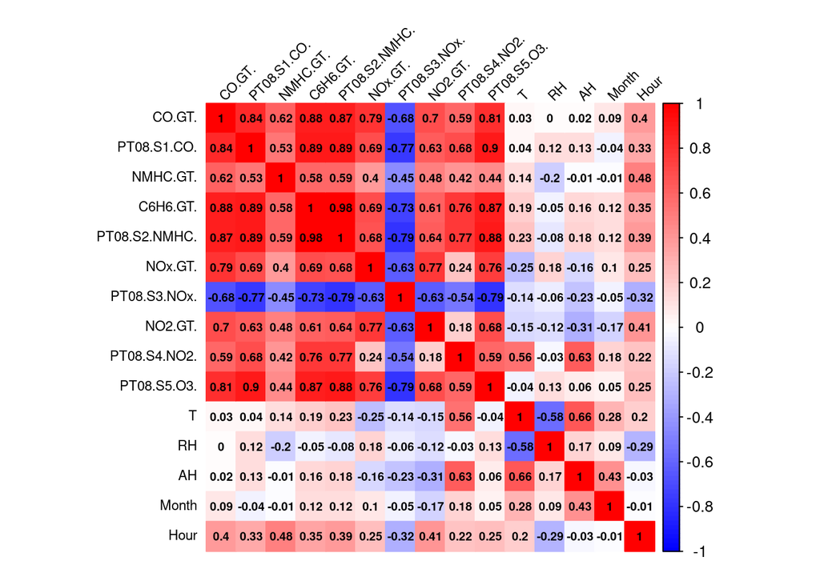

```r
library(ggplot2)
library(corrplot)
library(ggcorrplot)

# Calculate the correlation matrix
cor_matrix <- cor(df_air_train)

# Set the overall size of the plot (adjust as needed)
par(mfrow = c(1, 1), mar = c(0.5, 0.5, 0.5, 0.5),oma = c(1,1, 1, 1))

# Create a correlation heatmap with corrplot
corrplot(cor_matrix, method = "color", col = colorRampPalette(c("blue", "white", "red"))(100),
         addCoef.col = "black", tl.col = "black",tl.cex = 0.7,number.cex = 0.6, tl.srt = 45)
```

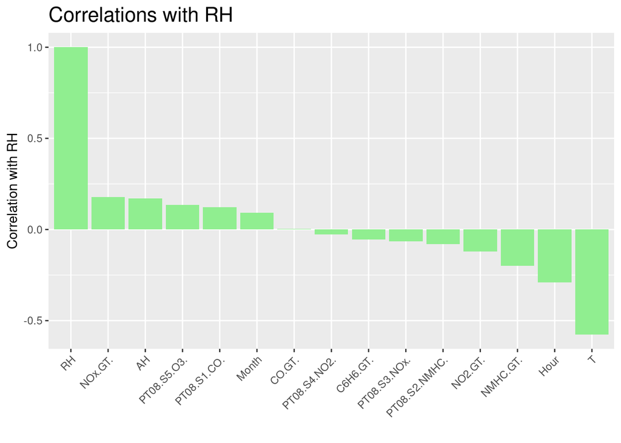

```r
corr_RH <- sort(cor(df_air_train)["RH",], decreasing = T)
corr_data <- data.frame(variable = names(corr_RH), correlation = corr_RH)

library(ggplot2)

ggplot(corr_data, aes(x = variable, y = correlation)) +
  geom_bar(stat = "identity", fill = "lightgreen") +
  scale_x_discrete(limits = corr_data$variable) +
  labs(x = "", y = "Correlation with RH", title = "Correlations with RH") +
  theme(plot.title = element_text(hjust = 0, size = rel(1.5)),
        axis.text.x = element_text(angle = 45, hjust = 1))
```

### Predictive analysis

```r
# Fit the linear regression model
linFit <- lm(log(RH) ~ T, data = df_air_train)

# Display the summary of the linear regression model
summary(linFit)
```

```
##
## Call:
## lm(formula = log(RH) ~ T, data = df_air_train)
##
## Residuals:
##     Min      1Q  Median      3Q     Max
## -1.4006 -0.2100  0.0621  0.2351  0.6888
##
## Coefficients:
##               Estimate Std. Error t value Pr(>|t|)
## (Intercept)  4.3291603  0.0094828  456.53   <2e-16 ***
## T           -0.0276164  0.0004666  -59.19   <2e-16 ***
## ---
## Signif. codes:  0 '***' 0.001 '**' 0.01 '*' 0.05 '.' 0.1 ' ' 1
##
## Residual standard error: 0.3263 on 6294 degrees of freedom
## Multiple R-squared:  0.3576, Adjusted R-squared:  0.3575
## F-statistic:  3503 on 1 and 6294 DF,  p-value: < 2.2e-16
```

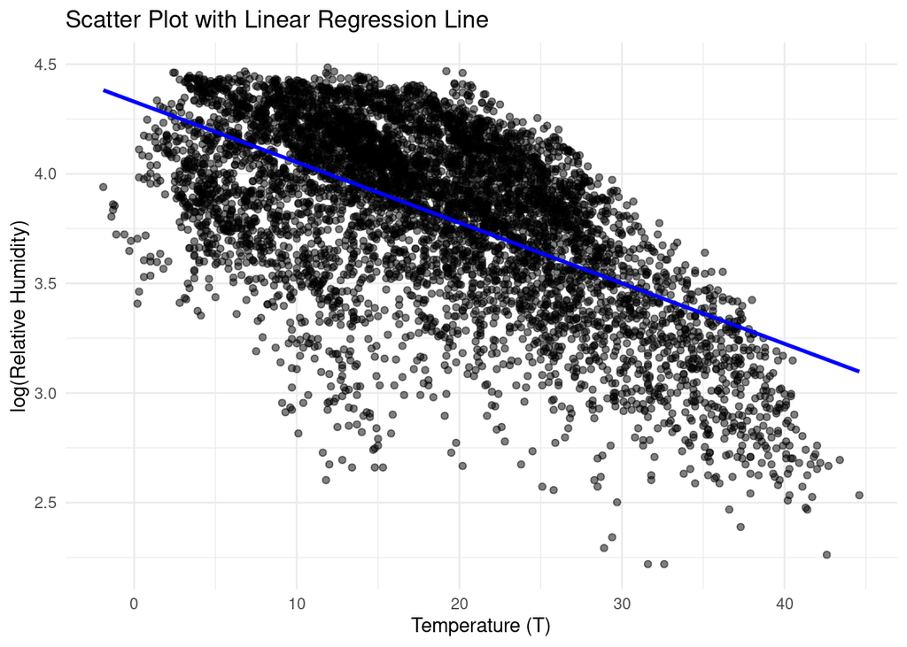

```r
# Create a scatter plot with the regression line
ggplot(df_air_train, aes(x = T, y = log(RH))) +
  geom_point(alpha = 0.5) +  # Scatter plot of the data points
  geom_smooth(method = "lm", se = FALSE, color = "blue") +  # Regression line
  labs(title = "Scatter Plot with Linear Regression Line",
       x = "Temperature (T)",
       y = "log(Relative Humidity)") +
  theme_minimal()
```